# Pertemuan 1 - Pemulusan

Akmal Basis Jatining Kusumah

##Library yang digunakan

```r
library("forecast")
```

```r
library("graphics")
library("TTR")
library("TSA")
```

## Impor Data

```r
library(rio)
data <- import("https://raw.githubusercontent.com/akmalbasisjkusumah/MPDW/main/Data/Dataset%20Tugas%201.csv")
head(data)
```

```
##   Bulan_Tahun Harga_Beras
## 1      Jan-13     7797.63
## 2      Feb-13     7773.26
## 3      Mar-13     7576.27
## 4      Apr-13     7420.72
## 5      May-13     7545.40
## 6      Jun-13     7548.22
```

## Eksplorasi Data

Mengubah data agar terbaca sebagai data deret waktu dengan fungsi `ts()` .

```r
data.ts <- ts(data$Harga_Beras)
```

Menampilkan ringkasan data

```r
summary(data.ts)
```

```
##    Min. 1st Qu.  Median    Mean 3rd Qu.    Max.
##    7421    9170    9524    9454    9815   11818
```

Membuat plot data deret waktu

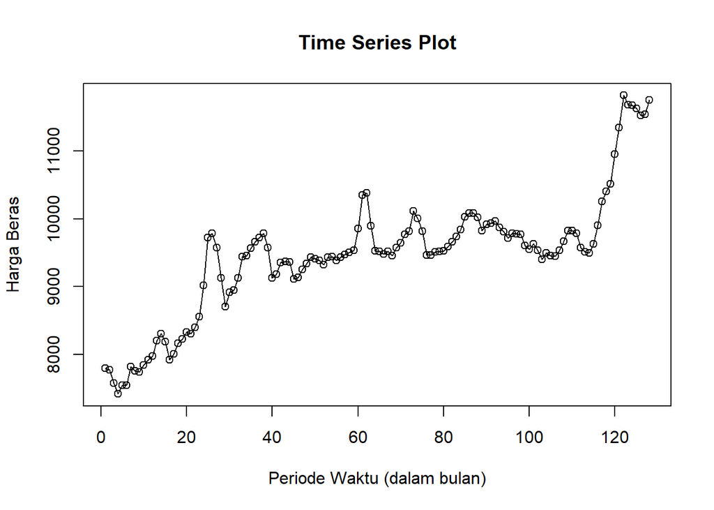

```r
ts.plot(data.ts, xlab="Periode Waktu (dalam bulan)", ylab="Harga Beras",
        main = "Time Series Plot")
points(data.ts)
```

```r
#Menyimpan Plot
dev.copy(png, "Plot Awal.png")
```

```r
dev.off()
```

## Single Moving Average & Double Moving Average

### Pembagian Data

Pembagian data latih dan data uji dilakukan dengan perbandingan 80% data latih dan 20% data uji.

```r
#membagi data latih dan data uji
training_ma <- data[1:103,]
testing_ma <- data[104:128,]
train_ma.ts <- ts(training_ma$Harga_Beras)
test_ma.ts <- ts(testing_ma$Harga_Beras)
```

### Eksplorasi Data

Eksplorasi data dilakukan pada keseluruhan data, data latih serta data uji menggunakan plot data deret waktu.

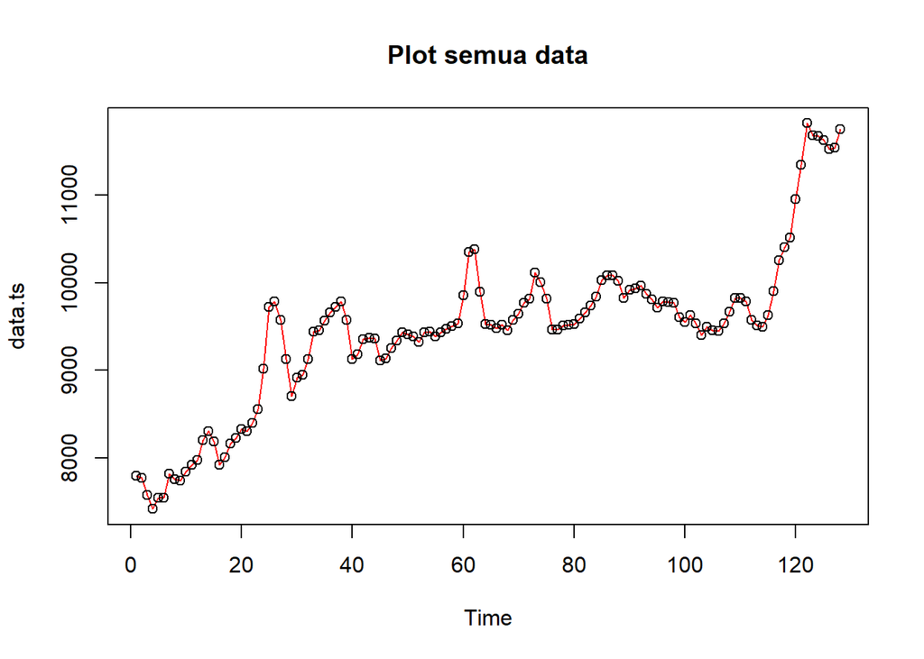

```r
#eksplorasi keseluruhan data
plot(data.ts, col="red",main="Plot semua data")
points(data.ts)
```

```r
dev.copy(png, "Plot Keseluruhan.png")
```

```r
dev.off()
```

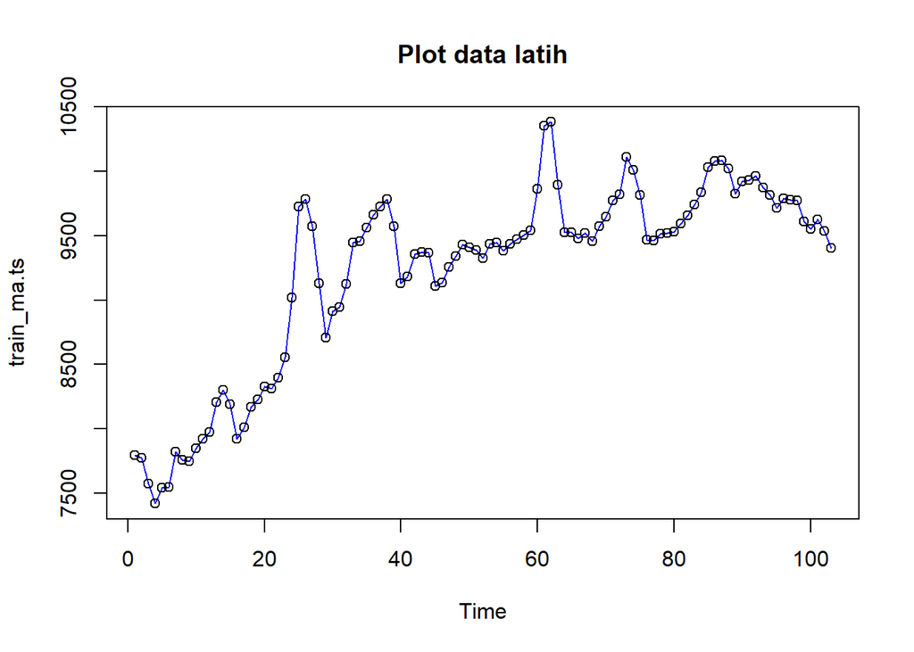

```r
#eksplorasi data latih
plot(train_ma.ts, col="blue",main="Plot data latih")
points(train_ma.ts)
```

```r
dev.copy(png, "Plot Data Train.png")
```

```r
dev.off()
```

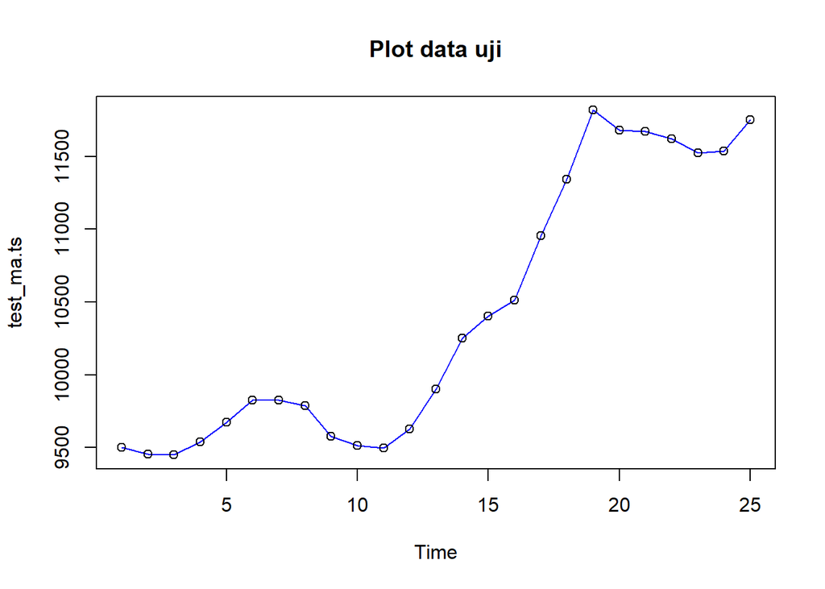

```r
#eksplorasi data uji
plot(test_ma.ts, col="blue",main="Plot data uji")
points(test_ma.ts)
```

```r
dev.copy(png, "Plot Data Uji.png")
```

```r
dev.off()
```

### Single Moving Average (SMA)

```r
data.sma<-SMA(train_ma.ts, n=5)
data.sma
```

```
## Time Series:
## Start = 1
## End = 103
## Frequency = 1
##   [1]        NA        NA        NA        NA  7622.656  7572.774  7582.858
##   [8]  7619.862  7684.952  7745.082  7819.434  7850.042  7939.542  8050.954
##  [15]  8120.318  8120.308  8126.850  8118.606  8103.620  8130.940  8209.056
##  [22]  8286.542  8364.056  8522.074  8800.872  9095.710  9330.706  9445.232
##  [29]  9383.516  9221.896  9053.978  8964.966  9028.224  9177.264  9307.044
##  [36]  9450.736  9570.072  9638.200  9661.566  9574.268  9477.940  9404.116
##  [43]  9322.050  9281.142  9277.704  9267.834  9248.438  9241.880  9254.694
##  [50]  9314.256  9365.446  9378.894  9397.816  9400.398  9395.456  9405.098
##  [57]  9434.296  9447.592  9466.486  9561.828  9744.462  9926.692 10004.670
##  [64] 10001.912  9934.610  9760.238  9587.876  9500.978  9510.392  9534.676
##  [71]  9593.260  9652.888  9783.490  9870.666  9904.512  9843.254  9772.050
##  [78]  9652.936  9555.224  9498.318  9524.260  9563.684  9609.014  9672.796
##  [85]  9773.328  9870.610  9955.262 10010.468 10008.142  9985.400  9955.582
##  [92]  9931.626  9902.212  9899.466  9858.576  9829.806  9793.314  9773.510
##  [99]  9732.324  9699.376  9667.220  9618.614  9544.516
```

Data pemulusan pada periode ke-t selanjutnya digunakan sebagai nilai peramalan pada periode ke t+1 sehingga hasil peramalan 1 periode kedepan adalah sebagai berikut.

```r
data.ramal<-c(NA,data.sma)
data.ramal #forecast 1 periode ke depan
```

```
##   [1]        NA        NA        NA        NA        NA  7622.656  7572.774
##   [8]  7582.858  7619.862  7684.952  7745.082  7819.434  7850.042  7939.542
##  [15]  8050.954  8120.318  8120.308  8126.850  8118.606  8103.620  8130.940
##  [22]  8209.056  8286.542  8364.056  8522.074  8800.872  9095.710  9330.706
##  [29]  9445.232  9383.516  9221.896  9053.978  8964.966  9028.224  9177.264
##  [36]  9307.044  9450.736  9570.072  9638.200  9661.566  9574.268  9477.940
##  [43]  9404.116  9322.050  9281.142  9277.704  9267.834  9248.438  9241.880
##  [50]  9254.694  9314.256  9365.446  9378.894  9397.816  9400.398  9395.456
##  [57]  9405.098  9434.296  9447.592  9466.486  9561.828  9744.462  9926.692
##  [64] 10004.670 10001.912  9934.610  9760.238  9587.876  9500.978  9510.392
##  [71]  9534.676  9593.260  9652.888  9783.490  9870.666  9904.512  9843.254
##  [78]  9772.050  9652.936  9555.224  9498.318  9524.260  9563.684  9609.014
##  [85]  9672.796  9773.328  9870.610  9955.262 10010.468 10008.142  9985.400
##  [92]  9955.582  9931.626  9902.212  9899.466  9858.576  9829.806  9793.314
##  [99]  9773.510  9732.324  9699.376  9667.220  9618.614  9544.516
```

```r
data.gab<-cbind(aktual=c(train_ma.ts,rep(NA,25)),pemulusan=c(data.sma,rep(NA,25)),ramalan=c(data.ramal,rep(data.ramal[length(data.ramal)],24)))
head(data.gab, 10) #forecast 25 periode ke depan
```

```
##        aktual pemulusan  ramalan
##  [1,] 7797.63        NA       NA
##  [2,] 7773.26        NA       NA
##  [3,] 7576.27        NA       NA
##  [4,] 7420.72        NA       NA
##  [5,] 7545.40  7622.656       NA
##  [6,] 7548.22  7572.774 7622.656
##  [7,] 7823.68  7582.858 7572.774
##  [8,] 7761.29  7619.862 7582.858
##  [9,] 7746.17  7684.952 7619.862
## [10,] 7846.05  7745.082 7684.952
```

Adapun plot data deret waktu dari hasil peramalan yang dilakukan adalah sebagai berikut.

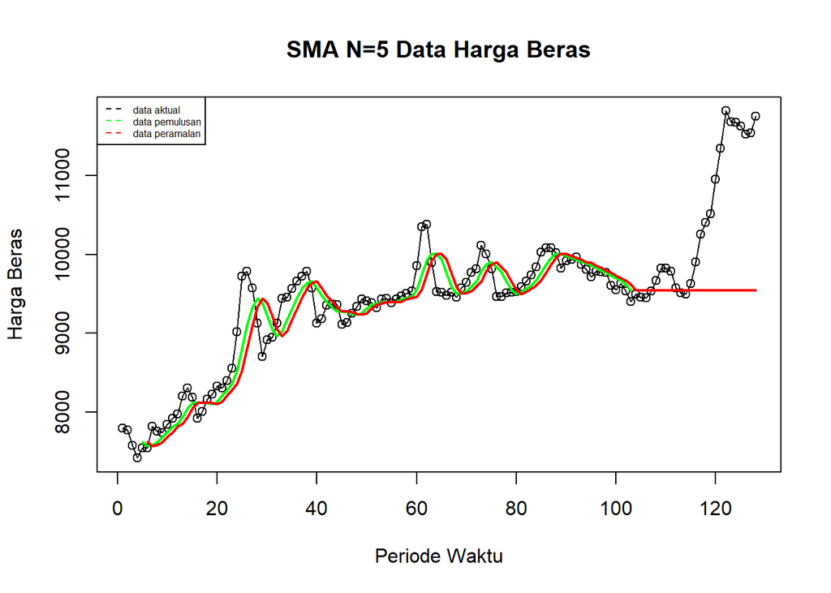

```r
ts.plot(data.ts, xlab="Periode Waktu", ylab="Harga Beras", main= "SMA N=5 Data Harga Beras")
points(data.ts)
lines(data.gab[,2],col="green",lwd=2)
lines(data.gab[,3],col="red",lwd=2)
legend("topleft",c("data aktual","data pemulusan","data peramalan"), lty=8, col=c("black","green","red"), cex=0.5)
```

```r
#Menyimpan Plot
dev.copy(png, "Plot Perbandingan Metode SMA.png")
```

```r
dev.off()
```

Selanjutnya perhitungan akurasi dilakukan dengan ukuran akurasi *Sum Squares Error* (SSE), *Mean Square Error* (MSE) dan *Mean Absolute Percentage Error* (MAPE). Perhitungan akurasi dilakukan baik pada data latih maupun pada data uji.

```r
#Menghitung nilai keakuratan data latih
error_train.sma = train_ma.ts-data.ramal[1:length(train_ma.ts)]
SSE_train.sma = sum(error_train.sma[6:length(train_ma.ts)]^2)
MSE_train.sma = mean(error_train.sma[6:length(train_ma.ts)]^2)
MAPE_train.sma = mean(abs((error_train.sma[6:length(train_ma.ts)]/train_ma.ts[6:length(train_ma.ts)])*100))

akurasi_train.sma <- matrix(c(SSE_train.sma, MSE_train.sma, MAPE_train.sma))
row.names(akurasi_train.sma)<- c("SSE", "MSE", "MAPE")
colnames(akurasi_train.sma) <- c("Akurasi m = 5")
akurasi_train.sma
```

```
##      Akurasi m = 5
## SSE   9.460318e+06
## MSE   9.653385e+04
## MAPE  2.453181e+00
```

Dalam hal ini nilai MAPE data latih pada metode pemulusan SMA kurang dari 5%, nilai ini dapat dikategorikan sebagai nilai akurasi yang sangat baik. Selanjutnya dilakukan perhitungan nilai MAPE data uji pada metde pemulusan SMA.

```r
#Menghitung nilai keakuratan data uji
error_test.sma = test_ma.ts-data.gab[104:128,3]
SSE_test.sma = sum(error_test.sma^2)
MSE_test.sma = mean(error_test.sma^2)
MAPE_test.sma = mean(abs((error_test.sma/test_ma.ts*100)))

akurasi_test.sma <- matrix(c(SSE_test.sma, MSE_test.sma, MAPE_test.sma))
row.names(akurasi_test.sma)<- c("SSE", "MSE", "MAPE")
colnames(akurasi_test.sma) <- c("Akurasi m = 5")
akurasi_test.sma
```

```
##      Akurasi m = 5
## SSE   3.915365e+07
## MSE   1.566146e+06
## MAPE  7.905219e+00
```

### Double Moving Average (DMA)

Metode pemulusan Double Moving Average (DMA) pada dasarnya mirip dengan SMA. Namun demikian, metode ini lebih cocok digunakan untuk pola data trend. Proses pemulusan dengan rata rata dalam metode ini dilakukan sebanyak 2 kali.

```r
dma <- SMA(data.sma, n = 5)
At <- 2*data.sma - dma
Bt <- 2/(5-1)*(data.sma - dma)
data.dma<- At+Bt
data.ramal2<- c(NA, data.dma)

t = 1:25
f = c()

for (i in t) {
  f[i] = At[length(At)] + Bt[length(Bt)]*(i)
}

data.gab2 <- cbind(aktual = c(train_ma.ts,rep(NA,25)), pemulusan1 = c(data.sma,rep(NA,25)),pemulusan2 = c(data.dma, rep(NA,25)),At = c(At, rep(NA,25)), Bt = c(Bt,rep(NA,25)),ramalan = c(data.ramal2, f[-1]))
head(data.gab2,10)
```

```
##        aktual pemulusan1 pemulusan2       At      Bt  ramalan
##  [1,] 7797.63         NA         NA       NA      NA       NA
##  [2,] 7773.26         NA         NA       NA      NA       NA
##  [3,] 7576.27         NA         NA       NA      NA       NA
##  [4,] 7420.72         NA         NA       NA      NA       NA
##  [5,] 7545.40   7622.656         NA       NA      NA       NA
##  [6,] 7548.22   7572.774         NA       NA      NA       NA
##  [7,] 7823.68   7582.858         NA       NA      NA       NA
##  [8,] 7761.29   7619.862         NA       NA      NA       NA
##  [9,] 7746.17   7684.952   7787.449 7753.284 34.1658       NA
## [10,] 7846.05   7745.082   7901.047 7849.058 51.9882 7787.449
```

Hasil pemulusan menggunakan metode DMA divisualisasikan sebagai berikut

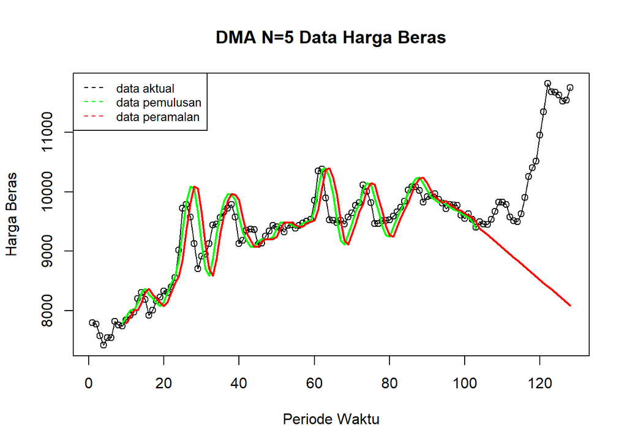

```r
ts.plot(data.ts, xlab="Periode Waktu", ylab="Harga Beras", main= "DMA N=5 Data Harga Beras")
points(data.ts)
lines(data.gab2[,3],col="green",lwd=2)
lines(data.gab2[,6],col="red",lwd=2)
legend("topleft",c("data aktual","data pemulusan","data peramalan"), lty=8, col=c("black","green","red"), cex=0.8)
```

```r
#Menyimpan Plot
dev.copy(png, "Plot Perbandingan Metode DMA.png")
```

```r
dev.off()
```

Selanjutnya perhitungan akurasi dilakukan baik pada data latih maupun data uji. Perhitungan akurasi dilakukan dengan ukuran akurasi SSE, MSE dan MAPE.

```r
#Menghitung nilai keakuratan data latih
error_train.dma = train_ma.ts-data.ramal2[1:length(train_ma.ts)]
SSE_train.dma = sum(error_train.dma[10:length(train_ma.ts)]^2)
MSE_train.dma = mean(error_train.dma[10:length(train_ma.ts)]^2)
MAPE_train.dma = mean(abs((error_train.dma[10:length(train_ma.ts)]/train_ma.ts[10:length(train_ma.ts)])*100))

akurasi_train.dma <- matrix(c(SSE_train.dma, MSE_train.dma, MAPE_train.dma))
row.names(akurasi_train.dma)<- c("SSE", "MSE", "MAPE")
colnames(akurasi_train.dma) <- c("Akurasi m = 5")
akurasi_train.dma
```

```
##      Akurasi m = 5
## SSE   1.183569e+07
## MSE   1.259116e+05
## MAPE  2.648982e+00
```

Perhitungan akurasi pada data latih menggunakan nilai MAPE menghasilkan nilai MAPE yang kurang dari 5% sehingga dikategorikan sangat baik. Selanjutnya, perhitungan nilai akurasi dilakukan pada data uji.

```r
#Menghitung nilai keakuratan data uji
error_test.dma = test_ma.ts-data.gab2[104:128,6]
SSE_test.dma = sum(error_test.dma^2)
MSE_test.dma = mean(error_test.dma^2)
MAPE_test.dma = mean(abs((error_test.dma/test_ma.ts*100)))

akurasi_test.dma <- matrix(c(SSE_test.dma, MSE_test.dma, MAPE_test.dma))
row.names(akurasi_test.dma)<- c("SSE", "MSE", "MAPE")
colnames(akurasi_test.dma) <- c("Akurasi m = 5")
akurasi_test.dma
```

```
##      Akurasi m = 5
## SSE   1.104141e+08
## MSE   4.416564e+06
## MAPE  1.518030e+01
```

## Single Exponential Smoothing & Double Exponential Smoothing

Metode *Exponential Smoothing* adalah metode pemulusan dengan melakukan pembobotan menurun secara eksponensial. Nilai yang lebih baru diberi bobot yang lebih besar dari nilai terdahulu. Terdapat satu atau lebih parameter pemulusan yang ditentukan secara eksplisit, dan hasil pemilihan parameter tersebut akan menentukan bobot yang akan diberikan pada nilai pengamatan. Ada dua macam model, yaitu model tunggal dan ganda.

### Pembagian Data

Pembagian data latih dan data uji dilakukan dengan perbandingan 80% data latih dan 20% data uji.

```r
#membagi training dan testing
Periode1 <- c(1:103)
Periode2 <- c(104:128)
training <- cbind(data[1:103,],Periode1)
testing <- cbind(data[104:128,],Periode2)
train.ts <- ts(training$Harga_Beras)
test.ts <- ts(testing$Harga_Beras)
```

#Eksplorasi data dapat dilakukan menggunakan package `ggplot2` .

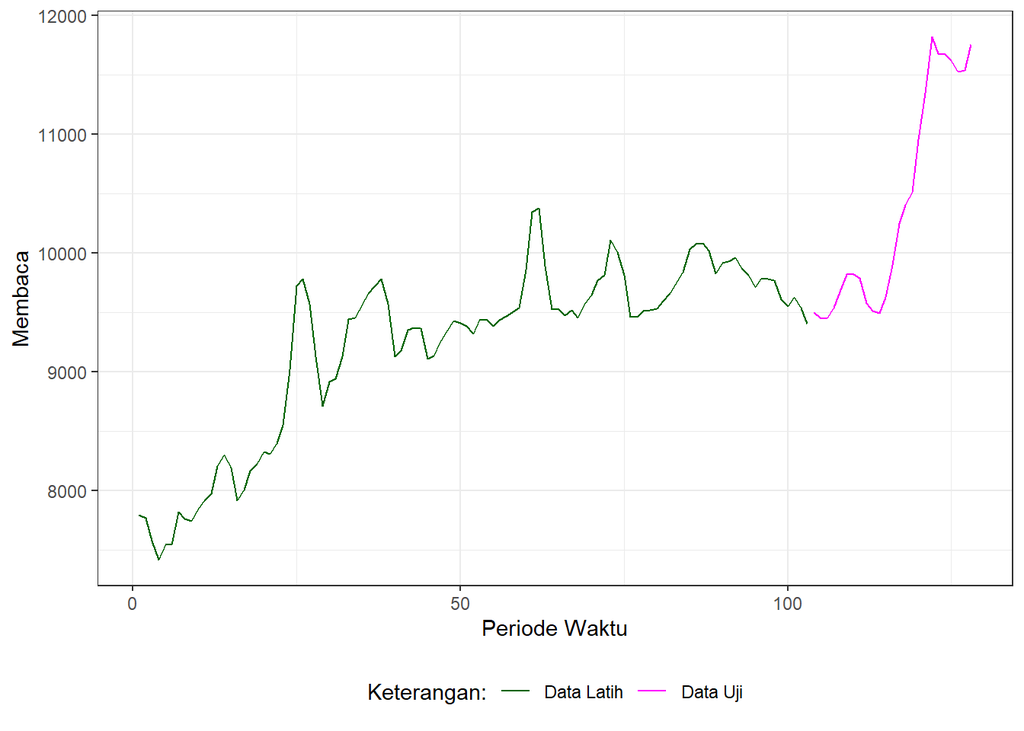

```r
#Eksplorasi dengan GGPLOT
library(ggplot2)
ggplot() +
  geom_line(data = training, aes(x = Periode1, y = Harga_Beras, col = "Data Latih")) +
  geom_line(data = testing, aes(x = Periode2, y = Harga_Beras, col = "Data Uji")) +
  labs(x = "Periode Waktu", y = "Membaca", color = "Legend") +
  scale_colour_manual(name="Keterangan:", breaks = c("Data Latih", "Data Uji"),
                      values = c("darkgreen", "magenta")) +
  theme_bw() + theme(legend.position = "bottom",
                     plot.caption = element_text(hjust=0.5, size=12))
```

```r
dev.copy(png, "Plot Split Data.png")
```

```r
dev.off()
```

### SES

Single Exponential Smoothing merupakan metode pemulusan yang tepat digunakan untuk data dengan pola stasioner atau konstan. Nilai pemulusan pada periode ke-t didapat dari persamaan:
$$\tilde{y}_T=\lambda y_t+(1-\lambda)\tilde{y}_{T-1}$$

Nilai parameter $\lambda$ adalah nilai antara 0 dan 1. Nilai pemulusan periode ke-t bertindak sebagai nilai ramalan pada periode ke-$(T+\tau)$.
$$\tilde{y}_{T+\tau}(T)=\tilde{y}_T$$

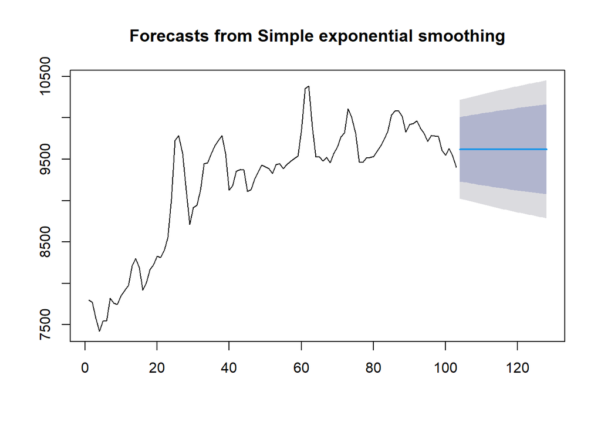

```r
#Cara 1 (fungsi ses)
ses.1 <- ses(train.ts, h = 25, alpha = 0.2)
plot(ses.1)
```

```r
ses.1
```

```
##     Point Forecast    Lo 80    Hi 80    Lo 95    Hi 95
## 104       9619.974 9231.280 10008.67 9025.518 10214.43
## 105       9619.974 9223.582 10016.37 9013.745 10226.20
## 106       9619.974 9216.031 10023.92 9002.197 10237.75
## 107       9619.974 9208.619 10031.33 8990.861 10249.09
## 108       9619.974 9201.338 10038.61 8979.725 10260.22
## 109       9619.974 9194.181 10045.77 8968.780 10271.17
## 110       9619.974 9187.143 10052.80 8958.016 10281.93
## 111       9619.974 9180.217 10059.73 8947.424 10292.52
## 112       9619.974 9173.399 10066.55 8936.996 10302.95
## 113       9619.974 9166.683 10073.26 8926.725 10313.22
## 114       9619.974 9160.065 10079.88 8916.604 10323.34
## 115       9619.974 9153.541 10086.41 8906.627 10333.32
## 116       9619.974 9147.107 10092.84 8896.787 10343.16
## 117       9619.974 9140.760 10099.19 8887.079 10352.87
## 118       9619.974 9134.495 10105.45 8877.499 10362.45
## 119       9619.974 9128.311 10111.64 8868.040 10371.91
## 120       9619.974 9122.203 10117.74 8858.699 10381.25
## 121       9619.974 9116.169 10123.78 8849.471 10390.48
## 122       9619.974 9110.207 10129.74 8840.352 10399.60
## 123       9619.974 9104.313 10135.63 8831.339 10408.61
## 124       9619.974 9098.486 10141.46 8822.428 10417.52
## 125       9619.974 9092.724 10147.22 8813.615 10426.33
## 126       9619.974 9087.024 10152.92 8804.897 10435.05
## 127       9619.974 9081.384 10158.56 8796.272 10443.68
## 128       9619.974 9075.802 10164.15 8787.736 10452.21
```

```r
ramalan1 <- forecast(ses.1, h=25)
dev.copy(png, "Plot SES (alpha = 0,2).png")
```

```r
dev.off()
```

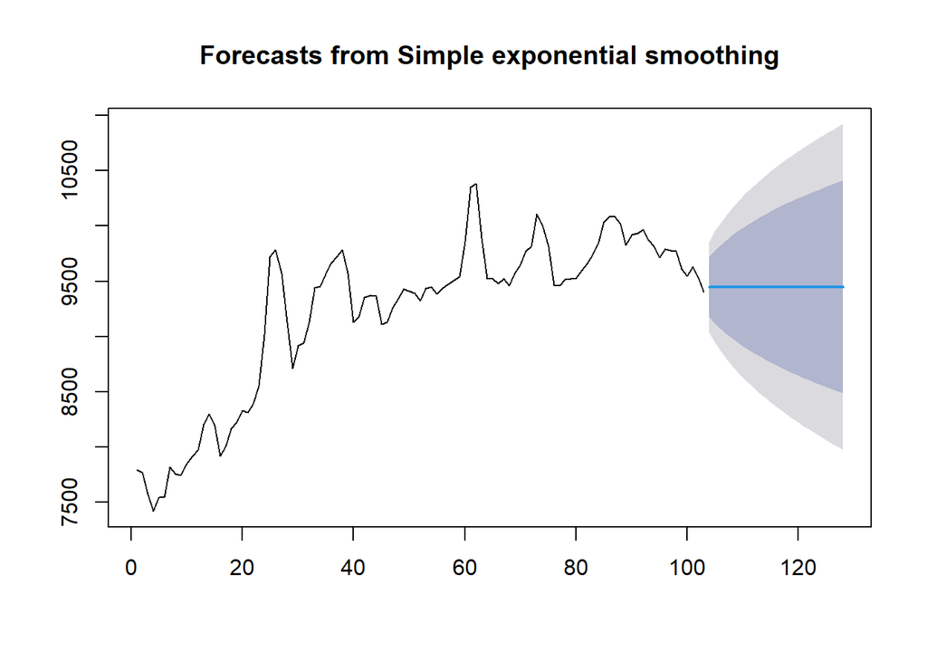

```r
ses.2<- ses(train.ts, h = 25, alpha = 0.7)
plot(ses.2)
```

```r
ses.2
```

```
##     Point Forecast    Lo 80     Hi 80    Lo 95     Hi 95
## 104        9449.15 9179.579  9718.721 9036.877  9861.423
## 105        9449.15 9120.097  9778.203 8945.907  9952.393
## 106        9449.15 9069.831  9828.469 8869.031 10029.269
## 107        9449.15 9025.487  9872.813 8801.213 10097.087
## 108        9449.15 8985.363  9912.937 8739.850 10158.451
## 109        9449.15 8948.445  9949.855 8683.388 10214.912
## 110        9449.15 8914.068  9984.232 8630.812 10267.488
## 111        9449.15 8881.770 10016.530 8581.417 10316.883
## 112        9449.15 8851.214 10047.086 8534.685 10363.615
## 113        9449.15 8822.145 10076.155 8490.229 10408.071
## 114        9449.15 8794.365 10103.935 8447.744 10450.557
## 115        9449.15 8767.718 10130.582 8406.989 10491.311
## 116        9449.15 8742.073 10156.227 8367.769 10530.531
## 117        9449.15 8717.327 10180.973 8329.923 10568.377
## 118        9449.15 8693.390 10204.910 8293.315 10604.985
## 119        9449.15 8670.189 10228.111 8257.832 10640.468
## 120        9449.15 8647.659 10250.641 8223.376 10674.924
## 121        9449.15 8625.746 10272.554 8189.862 10708.438
## 122        9449.15 8604.400 10293.900 8157.217 10741.083
## 123        9449.15 8583.581 10314.719 8125.376 10772.924
## 124        9449.15 8563.251 10335.049 8094.284 10804.016
## 125        9449.15 8543.377 10354.923 8063.890 10834.410
## 126        9449.15 8523.930 10374.370 8034.148 10864.152
## 127        9449.15 8504.883 10393.417 8005.019 10893.281
## 128        9449.15 8486.213 10412.087 7976.465 10921.835
```

```r
ramalan2 <- forecast(ses.2, h=25)
dev.copy(png, "Plot SES (alpha = 0,7.png")
```

```r
dev.off()
```

Untuk mendapatkan gambar hasil pemulusan pada data latih dengan fungsi `ses()` , perlu digunakan fungsi `autoplot()` dan `autolayer()` dari *library packages* `ggplot2` .

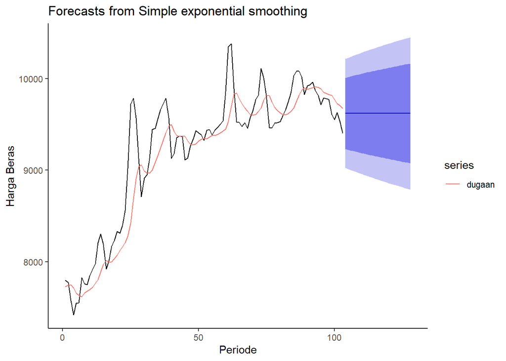

```r
autoplot(ses.1) +
  autolayer(fitted(ses.1), series="dugaan") +
  ylab("Harga Beras") + xlab("Periode") + theme_classic()
```

```r
dev.copy(png, "Perbandingan Plot SES (alpha = 0,2).png")
```

```r
dev.off()
```

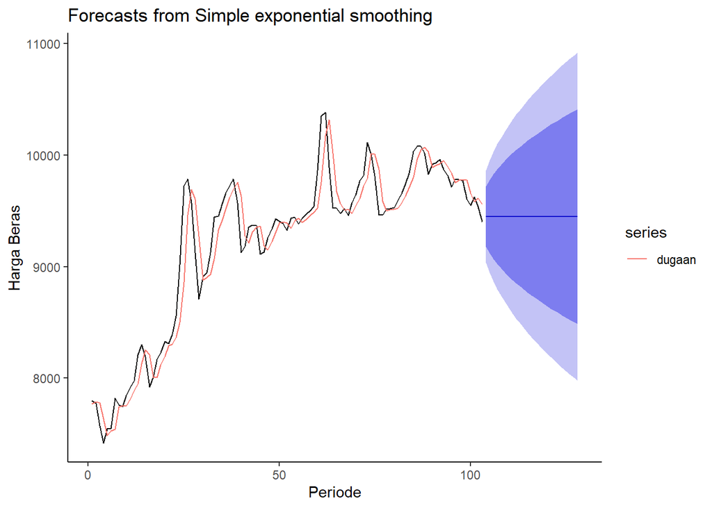

```r
autoplot(ses.2) +
  autolayer(fitted(ses.2), series="dugaan") +
  ylab("Harga Beras") + xlab("Periode") + theme_classic()
```

```r
dev.copy(png, "Perbandingan plot SES (alpha = 0,7).png")
```

```r
dev.off()
```

Pada fungsi `ses()` , terdapat beberapa argumen yang umum digunakan, yaitu nilia `y` , `gamma` , `beta` , `alpha` , dan `h` .

Nilai `y` adalah nilai data deret waktu, `gamma` adalah parameter pemulusan untuk komponen musiman, `beta` adalah parameter pemulusan untuk tren, dan `alpha` adalah parameter pemulusan untuk stasioner, serta `h` adalah banyaknya periode yang akan diramalkan.

Fungsi `HoltWinters` memiliki argumen yang sama dengan fungsi `ses()` . Argumen-argumen kedua fungsi dapat dilihat lebih lanjut dengan `?ses()` atau `?HoltWinters` .

Nilai parameter $\alpha$ dari kedua fungsi dapat dioptimalkan menyesuaikan dari *error*-nya paling minimumnya. Caranya adalah dengan membuat parameter $\alpha =$ `NULL` .

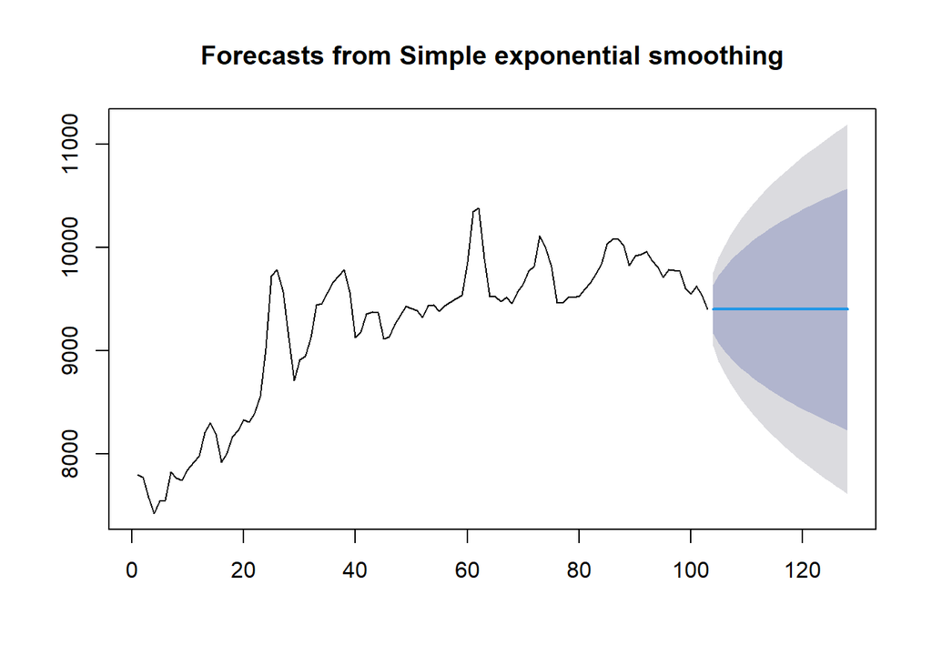

```r
#SES
ses.opt <- ses(train.ts, h = 25, alpha = NULL)
plot(ses.opt)
```

```r
ses.opt
```

```
##     Point Forecast    Lo 80     Hi 80    Lo 95     Hi 95
## 104       9401.624 9167.421  9635.826 9043.441  9759.806
## 105       9401.624 9070.427  9732.820 8895.103  9908.144
## 106       9401.624 8996.000  9807.248 8781.275 10021.972
## 107       9401.624 8933.253  9869.994 8685.313 10117.934
## 108       9401.624 8877.972  9925.275 8600.768 10202.479
## 109       9401.624 8827.994  9975.253 8524.333 10278.914
## 110       9401.624 8782.034 10021.213 8454.044 10349.203
## 111       9401.624 8739.256 10063.991 8388.620 10414.627
## 112       9401.624 8699.078 10104.169 8327.172 10476.075
## 113       9401.624 8661.076 10142.171 8269.054 10534.193
## 114       9401.624 8624.931 10178.316 8213.776 10589.472
## 115       9401.624 8590.396 10212.851 8160.958 10642.289
## 116       9401.624 8557.271 10245.976 8110.298 10692.949
## 117       9401.624 8525.398 10277.849 8061.553 10741.694
## 118       9401.624 8494.645 10308.602 8014.519 10788.728
## 119       9401.624 8464.900 10338.347 7969.029 10834.218
## 120       9401.624 8436.072 10367.175 7924.939 10878.308
## 121       9401.624 8408.079 10395.168 7882.129 10921.118
## 122       9401.624 8380.854 10422.393 7840.491 10962.756
## 123       9401.624 8354.336 10448.911 7799.936 11003.311
## 124       9401.624 8328.474 10474.773 7760.383 11042.864
## 125       9401.624 8303.220 10500.027 7721.760 11081.487
## 126       9401.624 8278.534 10524.713 7684.006 11119.241
## 127       9401.624 8254.379 10548.868 7647.064 11156.183
## 128       9401.624 8230.722 10572.525 7610.884 11192.363
```

```r
#ramalan
ramalanopt<- forecast(ses.opt, h=25)
ramalanopt
```

```
##     Point Forecast    Lo 80     Hi 80    Lo 95     Hi 95
## 104       9401.624 9167.421  9635.826 9043.441  9759.806
## 105       9401.624 9070.427  9732.820 8895.103  9908.144
## 106       9401.624 8996.000  9807.248 8781.275 10021.972
## 107       9401.624 8933.253  9869.994 8685.313 10117.934
## 108       9401.624 8877.972  9925.275 8600.768 10202.479
## 109       9401.624 8827.994  9975.253 8524.333 10278.914
## 110       9401.624 8782.034 10021.213 8454.044 10349.203
## 111       9401.624 8739.256 10063.991 8388.620 10414.627
## 112       9401.624 8699.078 10104.169 8327.172 10476.075
## 113       9401.624 8661.076 10142.171 8269.054 10534.193
## 114       9401.624 8624.931 10178.316 8213.776 10589.472
## 115       9401.624 8590.396 10212.851 8160.958 10642.289
## 116       9401.624 8557.271 10245.976 8110.298 10692.949
## 117       9401.624 8525.398 10277.849 8061.553 10741.694
## 118       9401.624 8494.645 10308.602 8014.519 10788.728
## 119       9401.624 8464.900 10338.347 7969.029 10834.218
## 120       9401.624 8436.072 10367.175 7924.939 10878.308
## 121       9401.624 8408.079 10395.168 7882.129 10921.118
## 122       9401.624 8380.854 10422.393 7840.491 10962.756
## 123       9401.624 8354.336 10448.911 7799.936 11003.311
## 124       9401.624 8328.474 10474.773 7760.383 11042.864
## 125       9401.624 8303.220 10500.027 7721.760 11081.487
## 126       9401.624 8278.534 10524.713 7684.006 11119.241
## 127       9401.624 8254.379 10548.868 7647.064 11156.183
## 128       9401.624 8230.722 10572.525 7610.884 11192.363
```

Setelah dilakukan peramalan, akan dilakukan perhitungan keakuratan hasil peramalan. Perhitungan akurasi ini dilakukan baik pada data latih dan data uji.

#### Akurasi Data Latih

Perhitungan akurasi data dapat dilakukan dengan cara langsung maupun manual. Secara langsung, nilai akurasi dapat diambil dari objek yang tersimpan pada hasil SES, yaitu *sum of squared errors* (SSE). Nilai akurasi lain dapat dihitung pula dari nilai SSE tersebut.

```r
#Keakuratan Metode
#Pada data training
SSE1<-sum(ses.1$residuals^2)
MSE1<-sum(ses.1$residuals^2)/length(train.ts)
RMSE1<-sqrt(MSE1)

akurasi1 <- matrix(c(SSE1,MSE1,RMSE1))
row.names(akurasi1)<- c("SSE", "MSE", "RMSE")
colnames(akurasi1) <- c("Akurasi lamda=0.2")
akurasi1
```

```
##      Akurasi lamda=0.2
## SSE       9291043.0054
## MSE         90204.3010
## RMSE          300.3403
```

```r
SSE2<-sum(ses.2$residuals^2)
MSE2<-sum(ses.2$residuals^2)/length(train.ts)
RMSE2<-sqrt(MSE2)

akurasi2 <- matrix(c(SSE2,MSE2,RMSE2))
row.names(akurasi2)<- c("SSE", "MSE", "RMSE")
colnames(akurasi2) <- c("Akurasi lamda=0.7")
akurasi2
```

```
##      Akurasi lamda=0.7
## SSE       4468831.7123
## MSE         43386.7157
## RMSE          208.2948
```

```r
#Cara Manual
fitted1<-ramalan1$fitted
sisaan1<-ramalan1$residuals
head(sisaan1)
```

```
## Time Series:
## Start = 1
## End = 6
## Frequency = 1
## [1]   68.73833   30.62066 -172.49347 -293.54478 -110.15582  -85.30466
```

```r
resid1<-training$`Harga_Beras`-ramalan1$fitted
head(resid1)
```

```
## Time Series:
## Start = 1
## End = 6
## Frequency = 1
## [1]   68.73833   30.62066 -172.49347 -293.54478 -110.15582  -85.30466
```

```r
SSE.1=sum(sisaan1[2:length(train.ts)]^2)
SSE.1
```

```
## [1] 9286318
```

```r
MSE.1 = SSE.1/length(train.ts)
MSE.1
```

```
## [1] 90158.43
```

```r
MAPE.1 = sum(abs(sisaan1[2:length(train.ts)]/train.ts[2:length(train.ts)])*
               100)/length(train.ts)
MAPE.1
```

```
## [1] 2.263718
```

```r
akurasi.1 <- matrix(c(SSE.1,MSE.1,MAPE.1))
row.names(akurasi.1)<- c("SSE", "MSE", "MAPE")
colnames(akurasi.1) <- c("Akurasi lamda=0.2")
akurasi.1
```

```
##      Akurasi lamda=0.2
## SSE       9.286318e+06
## MSE       9.015843e+04
## MAPE      2.263718e+00
```

```r
fitted2<-ramalan2$fitted
sisaan2<-ramalan2$residuals
head(sisaan2)
```

```
## Time Series:
## Start = 1
## End = 6
## Frequency = 1
## [1]   28.21793  -15.90462 -201.76139 -216.07842   59.85648   20.77694
```

```r
resid2<-training$`Harga_Beras`-ramalan2$fitted
head(resid2)
```

```
## Time Series:
## Start = 1
## End = 6
## Frequency = 1
## [1]   28.21793  -15.90462 -201.76139 -216.07842   59.85648   20.77694
```

```r
SSE.2=sum(sisaan2[2:length(train.ts)]^2)
SSE.2
```

```
## [1] 4468035
```

```r
MSE.2 = SSE.2/length(train.ts)
MSE.2
```

```
## [1] 43378.99
```

```r
MAPE.2 = sum(abs(sisaan2[2:length(train.ts)]/train.ts[2:length(train.ts)])*
               100)/length(train.ts)
MAPE.2
```

```
## [1] 1.551389
```

```r
akurasi.2 <- matrix(c(SSE.2,MSE.2,MAPE.2))
row.names(akurasi.2)<- c("SSE", "MSE", "MAPE")
colnames(akurasi.2) <- c("Akurasi lamda=0.7")
akurasi.2
```

```
##      Akurasi lamda=0.7
## SSE       4.468035e+06
## MSE       4.337899e+04
## MAPE      1.551389e+00
```

Berdasarkan nilai SSE, MSE, RMSE, dan MAPE di antara kedua parameter, nilai parameter $\lambda=0,7$ menghasilkan akurasi yang lebih baik dibanding $\lambda=0,2$ . Hal ini dilihat dari nilai masing-masing ukuran akurasi yang lebih kecil. Berdasarkan nilai MAPE-nya, hasil ini dapat dikategorikan sebagai peramalan sangat baik.

#### Akurasi Data Uji

Akurasi data uji dapat dihitung dengan cara yang hampir sama dengan perhitungan akurasi data latih. Selain dengan cara di atas, perhitungan nilai akurasi dapat menggunakan fungsi `accuracy()` dari *package* `forecast` . Penggunaannya yaitu dengan menuliskan `accuracy(hasil ramalan, kondisi aktual)` . Contohnya adalah sebagai berikut.

```r
accuracy(ramalanopt,testing$`Harga_Beras`)
```

```
##                      ME      RMSE       MAE      MPE     MAPE      MASE
## Training set   15.57594  180.9664  124.3519 0.162530 1.353905 0.9903493
## Test set     1008.29044 1354.2089 1008.2904 9.023303 9.023303 8.0301093
##                   ACF1
## Training set 0.4007424
## Test set            NA
```

### DES

Metode pemulusan *Double Exponential Smoothing* (DES) digunakan untuk data yang memiliki pola tren. Metode DES adalah metode semacam SES, hanya saja dilakukan dua kali, yaitu pertama untuk tahapan ‘level’ dan kedua untuk tahapan ‘tren’. Pemulusan menggunakan metode ini akan menghasilkan peramalan tidak konstan untuk periode berikutnya.

Pemulusan dengan metode DES kali ini akan menggunakan fungsi `HoltWinters()` . Jika sebelumnya nilai argumen `beta` dibuat `FALSE` , kali ini argumen tersebut akan diinisialisasi bersamaan dengan nilai `alpha` .

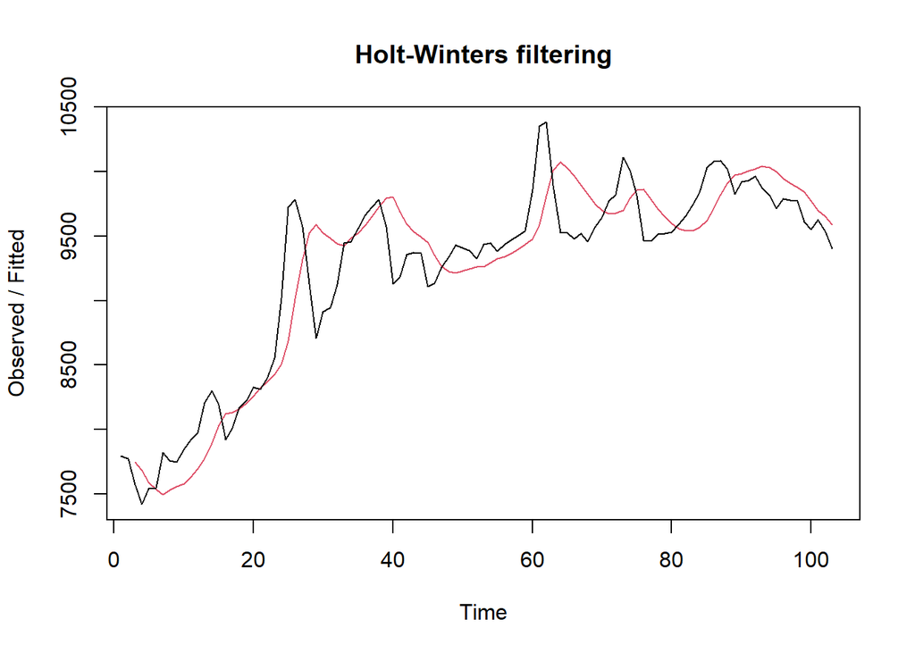

```r
#Lamda=0.2 dan gamma=0.2
des.1<- HoltWinters(train.ts, gamma = FALSE, beta = 0.2, alpha = 0.2)
plot(des.1)
```

```r
dev.copy(png, "Plot DES (alpha = 0,2).png")
```

```r
dev.off()
```

```r
#ramalan
ramalandes1<- forecast(des.1, h=25)
ramalandes1
```

```
##     Point Forecast    Lo 80    Hi 80    Lo 95    Hi 95
## 104       9504.844 9108.365 9901.323 8898.481 10111.21
## 105       9458.882 9051.144 9866.619 8835.301 10082.46
## 106       9412.920 8990.339 9835.500 8766.638 10059.20
## 107       9366.957 8925.742 9808.173 8692.177 10041.74
## 108       9320.995 8857.267 9784.723 8611.784 10030.21
## 109       9275.033 8784.936 9765.130 8525.494 10024.57
## 110       9229.071 8708.852 9749.290 8433.464 10024.68
## 111       9183.109 8629.172 9737.045 8335.936 10030.28
## 112       9137.146 8546.087 9728.206 8233.199 10041.09
## 113       9091.184 8459.798 9722.570 8125.563 10056.81
## 114       9045.222 8370.508 9719.936 8013.337 10077.11
## 115       8999.260 8278.409 9720.111 7896.814 10101.71
## 116       8953.298 8183.679 9722.917 7776.267 10130.33
## 117       8907.336 8086.480 9728.191 7651.946 10162.73
## 118       8861.373 7986.960 9735.787 7524.073 10198.67
## 119       8815.411 7885.247 9745.575 7392.848 10237.97
## 120       8769.449 7781.460 9757.438 7258.450 10280.45
## 121       8723.487 7675.701 9771.272 7121.037 10325.94
## 122       8677.525 7568.063 9786.986 6980.750 10374.30
## 123       8631.563 7458.628 9804.498 6837.713 10425.41
## 124       8585.600 7347.468 9823.733 6692.040 10479.16
## 125       8539.638 7234.650 9844.627 6543.831 10535.45
## 126       8493.676 7120.232 9867.120 6393.175 10594.18
## 127       8447.714 7004.269 9891.159 6240.155 10655.27
## 128       8401.752 6886.807 9916.696 6084.844 10718.66
```

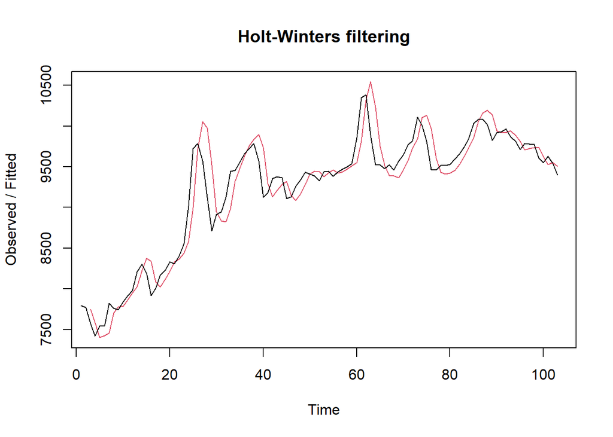

```r
#Lamda=0.6 dan gamma=0.3
des.2<- HoltWinters(train.ts, gamma = FALSE, beta = 0.3, alpha = 0.6)
plot(des.2)
```

```r
dev.copy(png, "Plot DES (alpha = 0,7).png")
```

```r
dev.off()
```

```r
#ramalan
ramalandes2<- forecast(des.2, h=25)
ramalandes2
```

```
##     Point Forecast    Lo 80     Hi 80     Lo 95     Hi 95
## 104       9387.588 9067.308  9707.867 8897.7618  9877.413
## 105       9331.715 8925.528  9737.903 8710.5051  9952.926
## 106       9275.843 8766.407  9785.280 8496.7277 10054.959
## 107       9219.971 8593.204  9846.738 8261.4134 10178.529
## 108       9164.099 8408.076  9920.122 8007.8613 10320.337
## 109       9108.227 8212.473 10003.981 7738.2902 10478.164
## 110       9052.355 8007.418 10097.292 7454.2613 10650.449
## 111       8996.483 7793.662 10199.303 7156.9278 10836.038
## 112       8940.611 7571.790 10309.431 6847.1800 11034.041
## 113       8884.739 7342.266 10427.211 6525.7304 11243.747
## 114       8828.866 7105.475 10552.258 6193.1669 11464.566
## 115       8772.994 6861.742 10684.247 5849.9861 11696.003
## 116       8717.122 6611.346 10822.898 5496.6157 11937.629
## 117       8661.250 6354.533 10967.968 5133.4300 12189.070
## 118       8605.378 6091.518 11119.238 4760.7607 12449.995
## 119       8549.506 5822.497 11276.515 4378.9050 12720.107
## 120       8493.634 5547.644 11439.624 3988.1314 12999.136
## 121       8437.762 5267.121 11608.403 3588.6847 13286.839
## 122       8381.890 4981.073 11782.707 3180.7888 13582.991
## 123       8326.018 4689.635 11962.400 2764.6506 13887.385
## 124       8270.145 4392.933 12147.358 2340.4612 14199.830
## 125       8214.273 4091.084 12337.463 1908.3988 14520.148
## 126       8158.401 3784.195 12532.608 1468.6294 14848.173
## 127       8102.529 3472.368 12732.690 1021.3087 15183.750
## 128       8046.657 3155.700 12937.615  566.5831 15526.731
```

Selanjutnya jika ingin membandingkan plot data latih dan data uji adalah sebagai berikut.

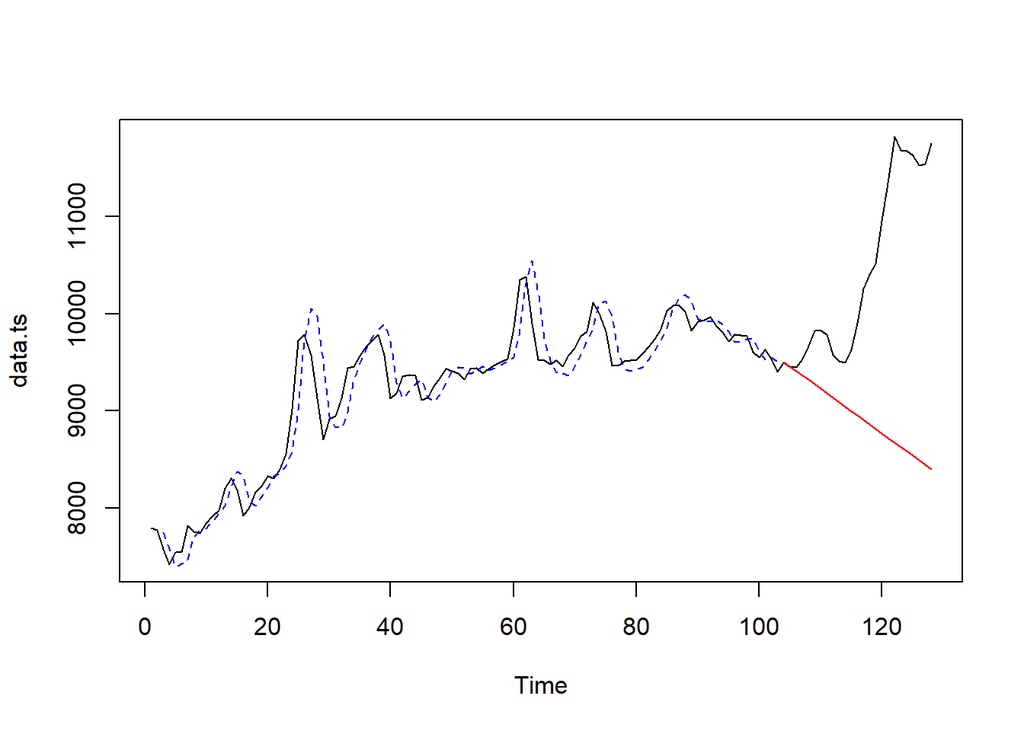

```r
#Visually evaluate the prediction
plot(data.ts)
lines(des.2$fitted[,1], lty=2, col="blue")
lines(ramalandes1$mean, col="red")
```

```r
dev.copy(png, "Plot Prediksi DES (alpha = 0,7).png")
```

```r
dev.off()
```

Untuk mendapatkan nilai parameter optimum dari DES, argumen `alpha` dan `beta` dapat dibuat `NULL`.

Selanjutnya akan dilakukan perhitungan akurasi pada data latih maupun data uji dengan ukuran akurasi SSE, MSE dan MAPE.

#### Akurasi Data Latih

```r
#Akurasi Data Training
ssedes.train1<-des.1$SSE
msedes.train1<-ssedes.train1/length(train.ts)
sisaandes1<-ramalandes1$residuals
head(sisaandes1)
```

```
## Time Series:
## Start = 1
## End = 6
## Frequency = 1
## [1]         NA         NA -172.62000 -262.37120  -43.44731   11.56969
```

```r
mapedes.train1 <- sum(abs(sisaandes1[3:length(train.ts)]/train.ts[3:length(train.ts)])
                      *100)/length(train.ts)

akurasides.1 <- matrix(c(ssedes.train1,msedes.train1,mapedes.train1))
row.names(akurasides.1)<- c("SSE", "MSE", "MAPE")
colnames(akurasides.1) <- c("Akurasi lamda=0.2 dan gamma=0.2")
akurasides.1
```

```
##      Akurasi lamda=0.2 dan gamma=0.2
## SSE                     9.574128e+06
## MSE                     9.295270e+04
## MAPE                    2.484104e+00
```

```r
ssedes.train2<-des.2$SSE
msedes.train2<-ssedes.train2/length(train.ts)
sisaandes2<-ramalandes2$residuals
head(sisaandes2)
```

```
## Time Series:
## Start = 1
## End = 6
## Frequency = 1
## [1]        NA        NA -172.6200 -169.1564  142.9072  120.1493
```

```r
mapedes.train2 <- sum(abs(sisaandes2[3:length(train.ts)]/train.ts[3:length(train.ts)])
                      *100)/length(train.ts)

akurasides.2 <- matrix(c(ssedes.train2,msedes.train2,mapedes.train2))
row.names(akurasides.2)<- c("SSE", "MSE", "MAPE")
colnames(akurasides.2) <- c("Akurasi lamda=0.6 dan gamma=0.3")
akurasides.2
```

```
##      Akurasi lamda=0.6 dan gamma=0.3
## SSE                     6.246089e+06
## MSE                     6.064164e+04
## MAPE                    1.809086e+00
```

Hasil akurasi dari data latih didapatkan skenario 2 dengan lamda=0.6 dan gamma=0.3 memiliki hasil yang lebih baik. Namun untuk kedua skenario dapat dikategorikan peramalan sangat baik berdasarkan nilai MAPE-nya.

#### Akurasi Data Uji

```r
#Akurasi Data Testing
selisihdes1<-ramalandes1$mean-testing$`Harga_Beras`
selisihdes1
```

```
## Time Series:
## Start = 104
## End = 128
## Frequency = 1
##  [1]     5.483844     3.321674   -36.550496  -172.332666  -351.544836
##  [6]  -549.197006  -597.809176  -603.521346  -439.603516  -421.445686
## [11]  -452.177856  -629.310026  -947.852197 -1344.974367 -1540.856537
## [16] -1696.298707 -2184.560877 -2621.613047 -3140.645217 -3049.527387
## [21] -3086.589557 -3083.971727 -3031.463897 -3089.726067 -3352.638237
```

```r
SSEtestingdes1<-sum(selisihdes1^2)
MSEtestingdes1<-SSEtestingdes1/length(testing$`Harga_Beras`)
MAPEtestingdes1<-sum(abs(selisihdes1/testing$`Harga_Beras`)*100)/length(testing$`Harga_Beras`)

selisihdes2<-ramalandes2$mean-testing$`Harga_Beras`
selisihdes2
```

```
## Time Series:
## Start = 104
## End = 128
## Frequency = 1
##  [1]  -111.7725  -123.8446  -173.6267  -319.3188  -508.4409  -716.0030
##  [7]  -774.5251  -790.1472  -636.1393  -627.8914  -668.5335  -855.5756
## [13] -1184.0277 -1591.0598 -1796.8519 -1962.2040 -2460.3761 -2907.3382
## [19] -3436.2803 -3355.0724 -3402.0445 -3409.3366 -3366.7387 -3434.9108
## [25] -3707.7329
```

```r
SSEtestingdes2<-sum(selisihdes2^2)
MSEtestingdes2<-SSEtestingdes2/length(testing$`Harga_Beras`)
MAPEtestingdes2<-sum(abs(selisihdes2/testing$`Harga_Beras`)*100)/length(testing$`Harga_Beras`)

akurasitestingdes <-
  matrix(c(SSEtestingdes1,MSEtestingdes1,MAPEtestingdes1,SSEtestingdes2,MSEtestingdes2,
           MAPEtestingdes2),
         nrow=3,ncol=3)
row.names(akurasitestingdes)<- c("SSE", "MSE", "MAPE")
colnames(akurasitestingdes) <- c("des ske1","des ske2","des opt")
akurasitestingdes
```

```
##          des ske1     des ske2      des opt
## SSE  8.993101e+07 1.127944e+08 8.993101e+07
## MSE  3.597241e+06 4.511777e+06 3.597241e+06
## MAPE 1.312137e+01 1.534594e+01 1.312137e+01
```

## Pemulusan Data Musiman

Pertama impor kembali data baru untuk latihan data musiman.

```r
#Import data
library(rio)
data3 <- import("https://raw.githubusercontent.com/akmalbasisjkusumah/MPDW/main/Data/Dataset%20Tugas%201.csv")
data3.ts <- ts(data3$Harga_Beras)
```

Selanjutnya melakukan pembagian data dan mengubahnya menjadi data deret waktu.

```r
#membagi data menjadi training dan testing
training<-data3[1:103,2]
testing<-data3[104:241,2]
training.ts<-ts(training, frequency = 12)
testing.ts<-ts(testing, frequency = 12)
```

Metode Holt-Winter untuk peramalan data musiman menggunakan tiga persamaan pemulusan yang terdiri atas persamaan untuk level $(L_t)$, trend $(B_t)$, dan komponen seasonal / musiman $(S_t)$ dengan parameter pemulusan berupa $\alpha$, $\beta$, dan $\gamma$. Metode Holt-Winter musiman terbagi menjadi dua, yaitu metode aditif dan metode multiplikatif.

Pemulusan data musiman dengan metode Winter dilakukan menggunakan fungsi `HoltWinters()` dengan memasukkan argumen tambahan, yaitu `gamma()` dan `seasonal()` . Arguman `seasonal()` diinisialisasi menyesuaikan jenis musiman, aditif atau multiplikatif.

### Winter Aditif

Perhitungan dengan model aditif dilakukan jika plot data asli menunjukkan fluktuasi musiman yang relatif stabil (konstan).

#### Pemulusan

```r
#Pemulusan dengan winter aditif
winter1 <- HoltWinters(training.ts,alpha=0.2,beta=0.1,gamma=0.1,seasonal = "additive")
head(winter1$fitted)
```

```
##           xhat    level    trend     season
## Jan 2 7939.827 7693.367 45.39304  201.06736
## Feb 2 8098.299 7792.552 50.77230  254.97403
## Mar 2 8036.608 7884.311 54.87092   97.42569
## Apr 2 7806.452 7970.434 57.99617 -221.97889
## May 2 7929.498 8051.126 60.26574 -181.89431
## Jun 2 8095.621 8127.378 61.86439  -93.62222
```

```r
xhat1 <- winter1$fitted[,2]

winter1.opt<- HoltWinters(training.ts, alpha= NULL,  beta = NULL, gamma = NULL, seasonal = "additive")
head(winter1.opt)
```

```
## $fitted
##            xhat     level     trend        season
## Jan 2  7939.827  7693.367 45.393039  201.06736111
## Feb 2  8298.689  7991.369 52.345196  254.97402778
## Mar 2  8197.868  8047.980 52.462579   97.42569444
## Apr 2  7926.103  8095.748 52.333387 -221.97888889
## May 2  8012.564  8142.284 52.173836 -181.89430556
## Jun 2  8149.985  8191.515 52.092835  -93.62222222
## Jul 2  8390.049  8260.123 52.547361   77.37819444
## Aug 2  8184.897  8160.756 48.366479  -24.22555556
## Sep 2  8309.890  8344.905 52.103400  -87.11930556
## Oct 2  8415.980  8397.592 52.119439  -33.73138889
## Nov 2  8483.443  8431.754 51.625234    0.06361111
## Dec 2  8615.858  8550.717 53.478467   11.66277778
## Jan 3  9263.557  8982.253 63.883113  217.42051136
## Feb 3  9809.098  9478.077 75.770706  255.25014162
## Mar 3  9703.195  9530.933 75.140070   97.12180410
## Apr 3  9332.095  9482.705 71.744799 -222.35419354
## May 3  9246.926  9362.547 66.463394 -182.08483840
## Jun 3  8884.579  8924.552 52.580011  -92.55306789
## Jul 3  9126.961  9006.042 53.375643   67.54375161
## Aug 3  8921.863  8888.623 48.675156  -15.43541448
## Sep 3  9096.647  9129.756 53.971864  -87.08157924
## Oct 3  9538.077  9510.019 62.951814  -34.89387731
## Nov 3  9560.182  9494.954 60.804709    4.42286167
## Dec 3  9656.636  9559.589 60.910118   36.13701502
## Jan 4  9933.484  9627.011 61.089340  245.38299734
## Feb 4  9800.274  9490.847 55.660642  253.76673324
## Mar 4  9676.274  9531.880 55.258085   89.13530879
## Apr 4  9306.836  9489.054 52.558684 -234.77733145
## May 4  9206.623  9373.435 47.930190 -214.74190460
## Jun 4  9354.784  9398.173 47.291926  -90.68154977
## Jul 4  9548.816  9445.049 47.280459   56.48707189
## Aug 4  9368.284  9328.489 42.771374   -2.97628047
## Sep 4  9347.123  9370.336 42.745927  -65.95857057
## Oct 4  9187.608  9190.921 36.631745  -39.94438592
## Nov 4  9215.750  9175.870 35.209382    4.67080991
## Dec 4  9323.003  9250.159 36.284909   36.55858799
## Jan 5  9573.270  9303.892 36.765094  232.61338906
## Feb 5  9493.301  9207.384 33.097249  252.81982272
```

[output cut: 80 more lines]

```
## $beta
##       beta
## 0.02752134
##
## $gamma
## gamma
##     1
##
## $coefficients
##           a           b          s1          s2          s3          s4
## 9413.722378    1.632938   -1.538956  -61.956051  -47.768525   -2.269287
##          s5          s6          s7          s8          s9         s10
##   53.906127  231.704717  238.908766   73.011472 -213.868803 -228.422774
##         s11         s12
## -132.528623  -12.112378
```

```r
head(winter1.opt$fitted)
```

```
##           xhat    level    trend     season
## Jan 2 7939.827 7693.367 45.39304  201.06736
## Feb 2 8298.689 7991.369 52.34520  254.97403
## Mar 2 8197.868 8047.980 52.46258   97.42569
## Apr 2 7926.103 8095.748 52.33339 -221.97889
## May 2 8012.564 8142.284 52.17384 -181.89431
## Jun 2 8149.985 8191.515 52.09283  -93.62222
```

```r
xhat1.opt <- winter1.opt$fitted[,2]
```

#### Peramalan

```r
#Forecast
forecast1 <- predict(winter1, n.ahead = 25)
forecast1.opt <- predict(winter1.opt, n.ahead = 25)
```

#### Plot Deret Waktu

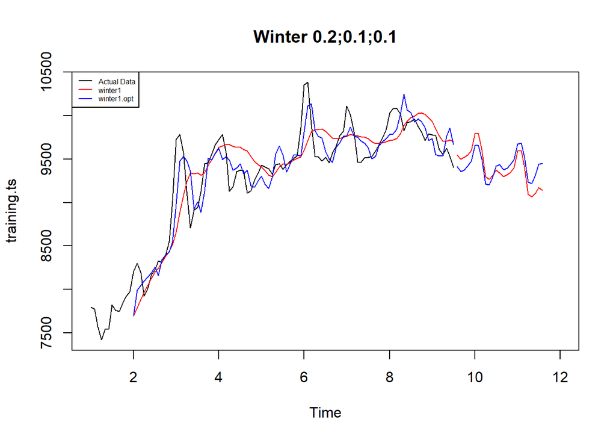

```r
#Plot time series
plot(training.ts,main="Winter 0.2;0.1;0.1",type="l",col="black",
     xlim=c(1,12),pch=12)
lines(xhat1,type="l",col="red")
lines(xhat1.opt,type="l",col="blue")
lines(forecast1,type="l",col="red")
lines(forecast1.opt,type="l",col="blue")
legend("topleft",c("Actual Data",expression(paste(winter1)),
                   expression(paste(winter1.opt))),cex=0.5,
       col=c("black","red","blue"),lty=1)
```

```r
dev.copy(png, "Plot Perbandingan Metode Winter Aditif.png")
```

```r
dev.off()
```

#### Akurasi Data Latih

```r
#Akurasi data training
SSE1<-winter1$SSE
MSE1<-winter1$SSE/length(training.ts)
RMSE1<-sqrt(MSE1)
akurasi1 <- matrix(c(SSE1,MSE1,RMSE1))
row.names(akurasi1)<- c("SSE", "MSE", "RMSE")
colnames(akurasi1) <- c("Akurasi")
akurasi1
```

```
##           Akurasi
## SSE  5470431.0073
## MSE    53110.9807
## RMSE     230.4582
```

```r
SSE1.opt<-winter1.opt$SSE
MSE1.opt<-winter1.opt$SSE/length(training.ts)
RMSE1.opt<-sqrt(MSE1.opt)
akurasi1.opt <- matrix(c(SSE1.opt,MSE1.opt,RMSE1.opt))
row.names(akurasi1.opt)<- c("SSE1.opt", "MSE1.opt", "RMSE1.opt")
colnames(akurasi1.opt) <- c("Akurasi")
akurasi1.opt
```

```
##                Akurasi
## SSE1.opt  2326454.5646
## MSE1.opt    22586.9375
## RMSE1.opt     150.2895
```

```r
akurasi1.train = data.frame(Model_Winter = c("Winter 1","Winter1 optimal"),
                            Nilai_SSE=c(SSE1,SSE1.opt),
                            Nilai_MSE=c(MSE1,MSE1.opt),Nilai_RMSE=c(RMSE1,RMSE1.opt))
akurasi1.train
```

```
##      Model_Winter Nilai_SSE Nilai_MSE Nilai_RMSE
## 1        Winter 1   5470431  53110.98   230.4582
## 2 Winter1 optimal   2326455  22586.94   150.2895
```

#### Akurasi Data Uji

```r
#Akurasi Data Testing
accuracy(forecast1.opt,testing[1:25])
```

```
##                ME     RMSE      MAE      MPE     MAPE
## Test set 983.2597 1328.361 983.2597 8.799546 8.799546
```

Dengan metode winter aditif didapatkan nilai MAPE kurang dari 10%

### Winter Multiplikatif

Model multiplikatif digunakan cocok digunakan jika plot data asli menunjukkan fluktuasi musiman yang bervariasi.

#### Pemulusan

```r
#Pemulusan dengan winter multiplikatif
winter2 <- HoltWinters(training.ts,alpha=0.2,beta=0.1,gamma=0.3,seasonal = "multiplicative")
head(winter2$fitted)
```

```
##           xhat    level    trend    season
## Jan 2 7932.430 7693.367 45.39304 1.0250259
## Feb 2 8091.291 7792.682 50.78530 1.0315961
## Mar 2 8034.334 7884.557 54.89426 1.0119508
## Apr 2 7809.263 7970.784 58.02753 0.9726548
## May 2 7931.070 8051.568 60.30311 0.9777115
## Jun 2 8096.297 8127.900 61.90604 0.9885823
```

```r
xhat2 <- winter2$fitted[,2]

winter2.opt<- HoltWinters(training.ts, alpha= NULL,  beta = NULL, gamma = NULL, seasonal = "multiplicative")
head(winter2.opt$fitted)
```

```
##           xhat    level    trend    season
## Jan 2 7932.430 7693.367 45.39304 1.0250259
## Feb 2 8291.086 7985.058 52.08477 1.0315961
## Mar 2 8197.079 8047.898 52.37696 1.0119508
## Apr 2 7925.920 8096.475 52.27372 0.9726548
## May 2 8012.585 8143.123 52.12088 0.9777115
## Jun 2 8150.206 8192.297 52.04080 0.9885823
```

```r
xhat2.opt <- winter2.opt$fitted[,2]
```

#### Peramalan

```r
#Forecast
forecast2 <- predict(winter2, n.ahead = 25)
forecast2.opt <- predict(winter2.opt, n.ahead = 25)
```

#### Plot Deret Waktu

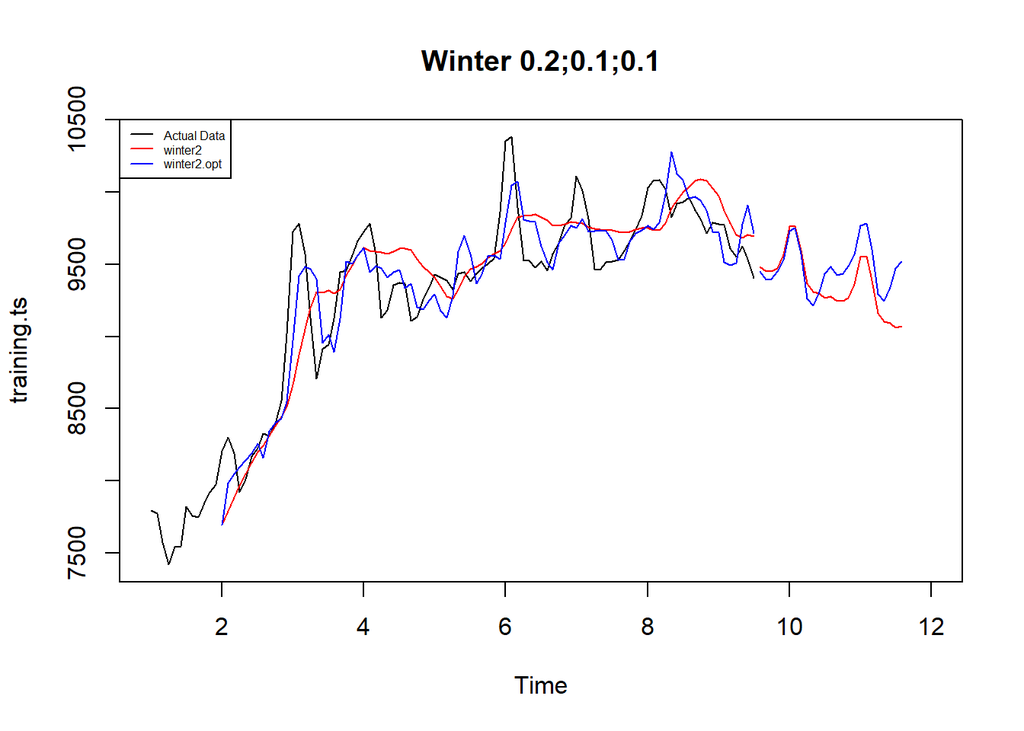

```r
#Plot time series
plot(training.ts,main="Winter 0.2;0.1;0.1",type="l",col="black",
     xlim=c(1,12),pch=12)
lines(xhat2,type="l",col="red")
lines(xhat2.opt,type="l",col="blue")
lines(forecast2,type="l",col="red")
lines(forecast2.opt,type="l",col="blue")
legend("topleft",c("Actual Data",expression(paste(winter2)),
                   expression(paste(winter2.opt))),cex=0.5,
       col=c("black","red","blue"),lty=1)
```

```r
dev.copy(png, "Plot Perbandingan Metode Winter Multiplikatif.png")
```

```r
dev.off()
```

#### Akurasi Data Latih

```r
#Akurasi data training
SSE2<-winter2$SSE
MSE2<-winter2$SSE/length(training.ts)
RMSE2<-sqrt(MSE2)
akurasi1 <- matrix(c(SSE2,MSE2,RMSE2))
row.names(akurasi1)<- c("SSE2", "MSE2", "RMSE2")
colnames(akurasi1) <- c("Akurasi lamda=0.2")
akurasi1
```

```
##       Akurasi lamda=0.2
## SSE2       5533898.7602
## MSE2         53727.1724
## RMSE2          231.7912
```

```r
SSE2.opt<-winter2.opt$SSE
MSE2.opt<-winter2.opt$SSE/length(training.ts)
RMSE2.opt<-sqrt(MSE2.opt)
akurasi1.opt <- matrix(c(SSE2.opt,MSE2.opt,RMSE2.opt))
row.names(akurasi1.opt)<- c("SSE2.opt", "MSE2.opt", "RMSE2.opt")
colnames(akurasi1.opt) <- c("Akurasi")
akurasi1.opt
```

```
##               Akurasi
## SSE2.opt  2454914.462
## MSE2.opt    23834.121
## RMSE2.opt     154.383
```

```r
akurasi2.train = data.frame(Model_Winter = c("Winter 1","winter2 optimal"),
                            Nilai_SSE=c(SSE2,SSE2.opt),
                            Nilai_MSE=c(MSE2,MSE2.opt),Nilai_RMSE=c(RMSE2,RMSE2.opt))
akurasi2.train
```

```
##      Model_Winter Nilai_SSE Nilai_MSE Nilai_RMSE
## 1        Winter 1   5533899  53727.17   231.7912
## 2 winter2 optimal   2454914  23834.12   154.3830
```

#### Akurasi Data Uji

```r
#Akurasi Data Testing
accuracy(forecast2.opt,testing[1:25])
```

```
##                ME     RMSE      MAE      MPE     MAPE
## Test set 932.9568 1286.871 932.9568 8.321221 8.321221
```

Dengan metode winter multiplikatif didapatkan nilai MAPE sebesar 8,32% yang hasilnya lebih baik dibandingkan metode winter multiplikatif